# Biweekly Report 7

# Jacob Tiede

## Using Atrous Spatial Pyramid Pooling with GANs

For this section I would again like to implement something that will help me with my project. I am interested in applying atrous convolution in addition to other techniques that I have already learned to make an attempt to improve the general structure of GANs as applied to various tasks. To this end I would like to understand how atrous convolutions and attention have been used in the literature already. For this section I will summarize this paper: https://arxiv.org/pdf/1901.06322.pdf. I think given how much I have learned from this class I will forgo much of the setup since I pretty much understood the method as it was written (without having to read outside sources), so I'll just start discussing the paper:

## The Generator

This model's contribution can be summarized quite well with this picture from the paper:

[figure not shown]

The major contribution from this paper is the SPAP module, where attention and atrous convolutions are used to augment the learning process. This will basically be the same as atrous pyramid pooling, but we'll add some attention modules. But, a relevant question is: why do we need this step?

The intuitions of this idea seems to me to be a problem associated with spatial pyramid pooling: resolution. With no padding each output from an atrous convolution with a different dilation rate will produce an output of a different size, so we zero pad to make sure we conconcatinate all of these outputs at different resolution scales together. This presents a problem because some pixels will contain less information in the output (since many of their values might be from the zero padding). This may slow down learning since if we were to just apply a convolution to a concatenated list then pixels where some are information dense and others have less information, then it might be hard to the network to single out which pixels are important. This presents a complex problem for a neural net to learn using just the basic tools of convolutions. This, I believe, is why attention is so useful here. By letting the network select only the pixels that are information dense we eliminate this complex learning problem. With that short explanation we can begin to look at how attention works in this network:

This module will start by finding and recording several outputs of atrous convolutions (as you would normally do with atrous spatial pooling). Instead of just concatenating these representations this module will try to combine only relevant parts from each representation using attention. Each attention module takes two inputs: one as a new resolution scale (an unprocessed atrous convolution output), and the processed representation that we learn from a previous attention module (except in the first 'fusion', which receives inputs from two unprocessed atrous convolutions). Our goal now is to create an information rich representation of both of these inputs. To do this we will create an attention path which will involve first concatenating these two representations and running them through a convolutional neural net which outputs two masks, one for each input. These masks are multiplied point wise with each of their respective inputs. This has the effect of not only discarding irrelevant pixels, but also potentially eliminating information that is redundant at each resolution scale. These two outputs are then concatenated and passed through another convolutional neural net to give the information dense output of the module. Applying this process to each resolution scale output gives a single information rich representation of the atrous spatial pyramid pooling process, which was our goal.

We then have a residual connection in this which allows the original input (not passed to any atrous convolutions) to skip to the complete fused representation. This involves a new learnable parameter $\gamma$ which will scale this residual connection. This has the effect of allowing the model to weigh the importance of the multiscale representation pooling, and just running a normal GAN. As one might expect, since this is almost the same as a residual learning module, the intended effect of this step is to make sure that our model will always outperform, or be on par with a simple generator structure. This is because learning a scaling of zero is very easy if none of the information from atrous spatial pyramid pooling is relevant, but just like in resnets usually we will see some positive effects by using this process.

### The Discriminator

It is worth noting that this paper also proposes a way of including a similar setup in the discriminator. While this did not change the results a great deal (the job of the discriminator is simple, and so it cannot benefit as much from the increased resolutions), the authors do include a means to implement this method without significantly increasing the number of parameters in the model, which is interesting enough to talk about. To better understand this aspect of the model I will quickly review the paper which the authors are drawing inspiration from (found here: https://arxiv.org/pdf/1805.04574.pdf).

#### Understanding Atrous Convolutions in Weakly Supervised Segmentations

This paper: https://arxiv.org/pdf/1805.04574.pdf seeks to improve the performance of weakly supervised segmentation algorithms. This being the case we should first define what 'weakly supervised' means in this context:

Consider the normal task of segmentation (with strong supervision), and what we would need to do such a task. We would need fully annotated images where a human has painstakingly annotated an image with every object in the image. Just getting this data is extremely difficult, but what's the alternative? Weakly supervised image segmentation seeks to use only information that is more readily available, like labels, or lists of what objects exist in the image, to accomplish the segmentation task. This is difficult since so much less information is contained in this data, but it does carry an advantage of having a much larger corpus of data. In general these methods train a network to classify objects, then they use some algorithm for quantifying feature importances (such as one of the many that we learned in class) to do the segmentation.

Now that we understand the problem the authors are addressing we need to know how they seek to improve over other approaches. They state that the main problem with prior papers was that they could only learn small discriminative regions of the image. This seems to be because, in order to be efficient, a neural net trained for classification would only really need to look at a subset of the pixels that comprise an image to understand what it is. This is analogous to the fact that I don't need to look at the hooves of a moose to understand that what I'm looking at is a moose. The authors theorize that this problem might be mitigated by employing atrous convolutions in a novel way to increase the size of the network's visual field without increasing the size of the network.

The really important parts of this paper are not so much in the details of how to do semi-supervised image segmentation, but rather how they use atrous convolutions. They first get many multi-resolution filter reads, and then they average them (they first apply an algorithm for feature attribution, then average, but this is a small detail for us). This means that rather than having a bunch of dilated convolutions followed by an interpretive network (as we would have if we just did atrous spatial pyramid pooling) which would add a ton of parameters to the model, we only need to add the parameters of the convolutions (a relatively small number).

What's interesting about this application is that the mean actually means something here. In this application they produce an activation map for each dilated convolution, each of which sees different features at different resolutions. By applying the average (rather than having another neural net interpret all of the resolutions together) we are able to get an 'average importance' of each pixel at each resolution scale. This gives an extremely simple way of combining atrous convolution that adds almost no parameters in comparison to other methods. But why is this relevant for our GAN architecture?

#### Utilizing this in our GAN

What the authors are exploiting about the discriminator's task is its simplicity. Since the task of binary classification (real or fake images in this case) is so much simpler than the task of generating fake examples we can more easily justify the use of the mean when combining filters at different resolutions. Consider what information exists at each dilated convolution's output for a discriminator. Each one (we hope) is saying something about whether a particular resolution believes that the image is real or fake. This means that if one resolution is really sure about it's answer, but the others aren't really sure we might still trust just the one that is sure. Giving each a 'vote' proportional to how 'sure' each convolution is that the image is real or fake is exactly what taking the mean of each dilated convolution is doing. This is why the authors employ the following scheme to incorporate dilated convolutions into the discriminator:

[figure not shown]

At any layer we want we can add a set of dilated convolutions which we will take the mean of. We will then use this mean, and take the mean of the non-dilated convolution. This will produce a sort of 'voting' for each resolution level.

## Implementation

I'll implement this on the MNIST dataset (https://www.kaggle.com/vikramtiwari/pix2pix-dataset) since it should be easier to see if it is working since I have a similar setup to this method already implemented in my first and second biweekly reports. We can now implement this:

```python
import torch
import torch.nn as nn
import torch.nn.functional as F
import pandas as pd
import numpy as np
import time
import torchvision.models as models
from sklearn.metrics import accuracy_score
import matplotlib.pyplot as plt
from PIL import Image
import torchvision.transforms.functional as TF
import torchvision.transforms as transforms
import os
import matplotlib.pyplot as plt
import progressbar #If you're missing this library it is found here: https://pypi.org/project/progressbar2/
print("Is a GPU available? ")
torch.cuda.is_available()
```

```
Is a GPU available?
```

```
True
```

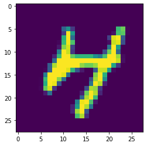

```python
#To start we will load and format the training data in python:

trainData = pd.read_csv("./Data/MNIST_train.csv")
#Lets start by getting all of the '4's in the dataset
trainData = trainData[trainData['label'] == 4]
train_y = trainData['label'].to_numpy()
train_x = trainData.to_numpy()
train_x = train_x[:,1:train_x.shape[1]]
#turn our data into torch tensors
train_y = torch.from_numpy(train_y)
train_x = torch.from_numpy(train_x)
#We now need to reshape train_x so that it is in the correct format for the image classifier
train_x = train_x.view(train_x.shape[0], 1, int(np.sqrt(train_x.shape[1])), int(np.sqrt(train_x.shape[1])))

#Now we'll look an image and write a function that will take a tensor and show the plot of the image
import matplotlib.pyplot as plt

def TImShow(image):
    image = image[0,:,:]
    #need to be in cpu to use the numpy() command
    plt.imshow(image.cpu().detach().numpy())
    plt.show()
TImShow(train_x[1,:,:,:])
```

I'll start by implementing the attentive fuse module:

```python
"""
AttentiveFuse -- implements an attentive fuse operation as detailed by https://arxiv.org/pdf/1901.06322.pdf

@params - c_in: the number of input channels (it will output 1/2 this number, since that will keep the number of filters constant
                in the large network)
          c_out: The number of output channels in the convolutional layer
"""
class AttentiveFuse(nn.Module):
    def __init__(self, c_in, c_out):
        super(AttentiveFuse, self).__init__()
        self.c_in = c_in
        self.c_out = c_out
        #----------
        #The first convolutional layers:
        #----------
        self.convLayers1 = nn.Sequential(nn.Conv2d(self.c_in, self.c_out, 3, padding = 1),
                                        nn.ReLU(),
                                        nn.BatchNorm2d(self.c_out),
                                        nn.Conv2d(self.c_out, 2*self.c_out, 3, padding = 1),
                                        nn.ReLU(),
                                        nn.BatchNorm2d(2*self.c_out),
                                        nn.Conv2d(2*self.c_out, self.c_in, 3, padding = 1),
                                        nn.Sigmoid(),
                                        nn.BatchNorm2d(self.c_in))
        #----------
        #The second convolutional layers:
        #----------
        self.convLayers2 = nn.Sequential(nn.Conv2d(int(self.c_in/2), self.c_out, 3, padding = 1),
                                        nn.ReLU(),
                                        nn.BatchNorm2d(self.c_out),
                                        nn.Conv2d(self.c_out, int(self.c_in/2), 3, padding = 1),
                                        nn.ReLU(),
                                        nn.BatchNorm2d(int(self.c_in/2)))
    def forward(self, x, y):
        #----------
        #concatinate the two inputs
        #----------
        cat = torch.cat((x,y), dim = 1)

        #----------
        #apply the first convolutional layers
        #----------
        cat = self.convLayers1(cat)

        #----------
        #separate the attentive filters and multiply pointwise
        #----------
        x_att = cat[:,0:int(self.c_in/2),:,:]
        y_att = cat[:,int(self.c_in/2):cat.shape[1],:,:]

        x = x*x_att
        y = y*y_att

        #----------
        #add both of the inputs (scaled by attention) together
        #----------
        out = x+y

        #----------
        #Run out through the final convolutional layers
        #----------
        out = self.convLayers2(out)
        return out
```

Now I will try to implement the whole module:

```python
"""
SpatialPooling -- Implements attentive spatial pooling as defined by https://arxiv.org/pdf/1901.06322.pdf

@params - c_in - input channels
          c_out - number of channels in the inbetween networks
          dilationRates - what dilation rates should we use in our convolutions for ASPP
"""
from torch.nn.parameter import Parameter
class SpatialPooling(nn.Module):
    def __init__(self, c_in, c_out = 32, dilationRates = [3,6,12,18]):
        super(SpatialPooling, self).__init__()
        #----------
        #Initialize parameters
        #----------
        self.dilationRates = dilationRates
        self.c_in = c_in
        self.c_out = c_out
        self.atrousConvs = nn.ModuleList([]) #Keeps track of the set of atrous convolutions
        self.fuses = nn.ModuleList([]) #Keeps track of the fusing modules

        #----------
        #Populate atrous Convs and fuses modules lists
        #We need 1 less fusion module than we have atrous convolution representation (so we have an if statement to take care of this)
        #Each atrous conv in this module will follow the form atrous conv -> relu -> batch normalization
        #----------
        for i in self.dilationRates:
            if i != self.dilationRates[0]:
                self.fuses.append(AttentiveFuse(self.c_out*2, 32))
            self.atrousConvs.append(nn.Sequential(nn.Conv2d(self.c_in, self.c_out, 3, padding = i, dilation = i),
                                             nn.ReLU(),
                                             nn.BatchNorm2d(self.c_out)))
        #----------
        #In order to apply the residual connection we will need to reduce the dimension of the output to have the same number of filters as
        #the input
        #----------
        self.convReduce = nn.Sequential(nn.Conv2d(self.c_out, self.c_in, 1),
                                        nn.ReLU(),
                                        nn.BatchNorm2d(self.c_in))

        #----------
        #Initialize the gamma in the residual scaling
        #----------
        self.gamma = Parameter(torch.zeros(1,1))
        self.gamma = nn.init.xavier_uniform_(self.gamma)
    def forward(self, x):
        #----------
        #Save the original x for the skip connection
        #----------
        x_mem = x.clone()

        #----------
        #Do the atrous convolutions, keeping track of each one in a list
        #----------
        savedConvs = []
        for i in range(len(self.atrousConvs)):
            savedConvs.append(self.atrousConvs[i](x))

        #----------
        #Fuse together all of the atrous convolutions
        #----------
        for i in range(len(self.fuses)):
            if i == 0:
                out = self.fuses[i](savedConvs[i], savedConvs[i+1])
            else:
                out = self.fuses[i](out, savedConvs[i+1])

        #----------
        #Reduce the number of filters in out so that it is the same as that of the input
        #----------
        out = self.convReduce(out)

        #----------
        #Create a residual connection with a learned scaling
        #----------
        out = out*self.gamma + (1-self.gamma)*x_mem
        return out
```

Finally we have to implement the complete network:

```python
"""
Generator -- Defines a generator similar to the one defined here: https://arxiv.org/pdf/1901.06322.pdf

@params: c_in - how many input channels we should turn the noise into
         c_out - how many channels to use throughout the network
"""
class Generator(nn.Module):
    def __init__(self, c_in, c_out):
        super(Generator, self).__init__()
        self.c_in = c_in
        self.c_out = c_out
        #----------
        #first we take a 100 dimensional vector from the latent space, and we have a fully connected layer to upscale it to 7*7*c_in cube of
        #points
        #----------
        self.fc1 = nn.Sequential(nn.Linear(100,7*7*self.c_in),
                                 nn.ReLU())
        #----------
        #Now we'll add a layer to upsample this image to be 14x14
        #----------
        self.upsample1 = nn.Sequential(nn.ConvTranspose2d(self.c_in, self.c_in, 4, stride = 2, padding = 1),
                                       nn.ReLU(),
                                       nn.BatchNorm2d(self.c_in))

        #----------
        #Next we'll need to run this through Spatial Pooling module
        #----------
        self.spatialAttPool = SpatialPooling(self.c_in, self.c_out)

        #----------
        #Now we upsample to 28x28
        #----------
        self.upsample2 = nn.Sequential(nn.ConvTranspose2d(self.c_in, 128, 4, stride = 2, padding = 1),
                                       nn.ReLU(),
                                       nn.BatchNorm2d(128))
        self.finalConv = nn.Conv2d(128,1,7,padding=3)
    def forward(self, x):
        x = self.fc1(x)
        x = x.view(-1, self.c_in, 7, 7)
        x = self.upsample1(x)
        x = self.spatialAttPool(x)
        x = self.upsample2(x)
        x = torch.tanh(self.finalConv(x))
        return x
```

Now we can just take some code from the first biweekly report to train this:

```python
"""
Discriminator - implement a discriminator. This uses the skeleton from my first biweekly report, but I'm going to add ASPP as directed by
https://arxiv.org/pdf/1901.06322.pdf.
"""
class Discriminator(nn.Module):
    #Note that exImg will contain and example image which we can get the dimension of NOTE: this should have dimension (1, 1, height, width)
    #batchSize will be the size of the batches
    def __init__(self):
        super(Discriminator, self).__init__()
        # The article uses same padding, which is not trivial to implement in pytorch. We will use the padding function with
        #p = (filter size - 1)/2 = 1 to get same padding
        self.conv1 = nn.Conv2d(1, 64, 3, stride = 2, padding = 1)
        self.batchNorm1 = nn.BatchNorm2d(64)
        self.conv2 = nn.Conv2d(64, 64, 3, stride = 2, padding = 1)

        #-------
        #add dilated convolutions:
        #-------
        self.dilationRates = [3,6,9] #the original paper on this (semi-supervised semantic segmenation) recommends small dilation rates
        self.atrousConvs = nn.ModuleList([])
        for i in self.dilationRates:
            self.atrousConvs.append(nn.Sequential(nn.Conv2d(64, 64, 3, padding = i, dilation = i),
                                             nn.ReLU(),
                                             nn.BatchNorm2d(64)))

        self.batchNorm2 = nn.BatchNorm2d(64)
        self.leReLU = nn.LeakyReLU(.2)
        self.fc1 = nn.Linear(3136, 1)

    def forward(self, x):
        x = self.leReLU(self.conv1(x))
        x = self.batchNorm1(x)
        x = self.leReLU(self.conv2(x))
        x = self.batchNorm2(x)

        #-------
        #add the dilated convolutions
        #-------
        temp = []
        for i in range(len(self.atrousConvs)):
            temp.append(self.atrousConvs[i](x))
        #used this for help https://discuss.pytorch.org/t/get-the-mean-from-a-list-of-tensors/31989/4
        atrousOut = torch.mean(torch.stack(temp), 0)

        x = torch.mean(torch.stack([x,atrousOut]), 0)

        # Remember that view reshapes the tensor, so this is a flattening layer since it contains a -1 we will get an output shape of
        # (nSamples, nChannels * number of features (which has changed from the original due to the convolutions and pooling))
        x = x.view(-1, self.num_flat_features(x))
        x = self.fc1(x)
        return x
    #Gets the number of features after all of the dimensionality reduction is applied to x from the convolutions and maxpoolings
    def num_flat_features(self, x):
        # x's shape is originally nSamples, nChannels, Height, Width for images, so we want to compute nChannels * num features =
        # nChannels * Current Height * Current Width (current referring to after conv and pooling)
        size = x.shape[1:]  # all dimensions except the batch dimension
        num_features = 1
        for s in size:
            num_features *= s
        return num_features
```

```
The generator's first attempt at generating an image:
```

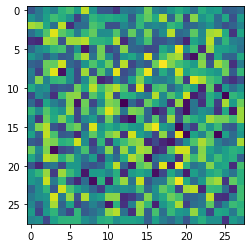

```
[2,    63] loss: 0.700
```

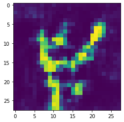

```
[4,    63] loss: 1.673
```

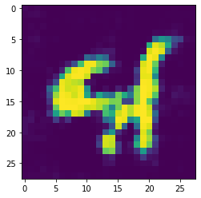

```
[6,    63] loss: 3.039
```

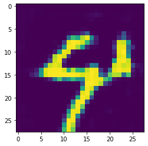

```
[8,    63] loss: 3.662
```

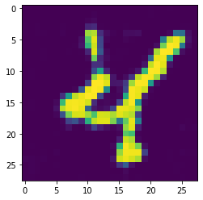

```
[10,    63] loss: 5.202
```

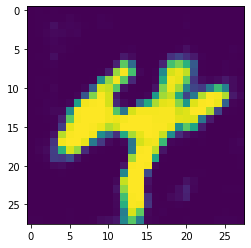

```
[12,    63] loss: 5.497
```

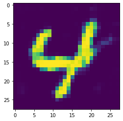

```
[14,    63] loss: 6.441
```

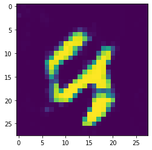

```
[16,    63] loss: 6.799
```

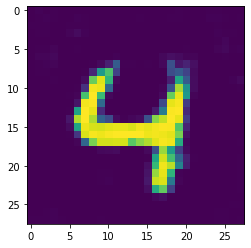

```
[18,    63] loss: 7.431
```

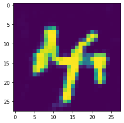

```
[20,    63] loss: 7.209
```

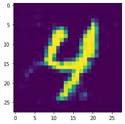

```
Done traininig
```

```python
def getRealSamples(data, batch_size):
    temp = torch.randperm(batch_size)
    result = data[temp, :, :, :]
    #rescale to match generator, normall grey scale ranges from [0,255], so to do this rescale we will subtrack by the mid point and divide by the mid point
    #(this will force all the values to be between -1 and 1)
    result = result.float()
    result = (result - 255/2)/(255/2)
    return result
gen = Generator(64,32).cuda()
dis = Discriminator().cuda()
batch_size = 64
#define our two optimizers
learning_rate = 5e-5
#Use two separate RMSprop optimizers, one for the generator and one for the discriminator
gOptimizer = torch.optim.RMSprop(gen.parameters(), lr=learning_rate)
dOptimizer = torch.optim.RMSprop(dis.parameters(), lr=learning_rate)
#Now we will define the training loop:
epochs = 20
batchesPerEpoch = int(np.floor(train_x.shape[0]/batch_size))
for epoch in range(epochs):
    running_gen_loss = 0
    for i in range(batchesPerEpoch):
        #number of times we train the critic for each training step on the generator
        criticConst = 5
        for j in range(criticConst):
            #set the gradients of the discriminator to zero
            dOptimizer.zero_grad()
            #generate a mini batch of gaussian noise
            genMiniBatch = torch.rand(batch_size, 100).float()
            genMiniBatch = genMiniBatch.cuda()
            #get a minibatch of the real data
            realMiniBatch = getRealSamples(train_x, batch_size)
            realMiniBatch = realMiniBatch.cuda()

            #Start by training the discriminator
            #Get Dx, the discriminator when applied to the minibatch of real data
            Dx = dis(realMiniBatch)
            #calculate the loss associated with this step
            dxLoss = -1*torch.mean(Dx)
            #find the gradients for this step
            dxLoss.backward()
            #generate fake images
            Gz = gen(genMiniBatch.float())
            #apply the discriminator to fake images
            Gz = Gz.view(batch_size, 1, 28, 28)
            Gz = Gz.cuda()
            DGz = dis(Gz)
            #Find the loss associated with this step
            dgzLoss = 1*torch.mean(DGz)
            #Accumulate the gradients for this half of the loss
            dgzLoss.backward()
            #set the total loss as the sum of our two previous losses
            dLoss = dgzLoss+dxLoss
            dOptimizer.step()
            #weight clipping. I used https://discuss.pytorch.org/t/set-constraints-on-parameters-or-layers/23620/7 as a reference
            #it appears that j.data will allow us to modify non-leaf nodes of our computational graph despite the fact that they require gradients.
            #It also appears that this feature is depreciated, and it shouldn't be used until after our optimizer has taken a step because it might mess
            #with the backpropogation. Note: the .clamp_ function does exactly what one would think (it makes sure that all the values of a tensor are
            #within the given range) and the _ denotes that the operation is an inplace operation.
            for j in dis.parameters():
                j.data.clamp_(-.1,.1)


        #set the generator's gradients to zero
        gOptimizer.zero_grad()
        genMiniBatch = torch.rand(batch_size*2, 100)
        genMiniBatch = genMiniBatch.cuda()
        #use the generator to make a new batch of images (even though we have already computed this we need to recompute it for pytorch to understand
        #how to backpropogate)
        Gz = gen(genMiniBatch.float())
        #apply the discriminator to the generated images
        Gz = Gz.view(batch_size*2, 1, 28, 28)
        Gz = Gz.cuda()
        DGz = dis(Gz)
        #calculate the loss
        gLoss = -1*torch.mean(DGz)
        #accumulate the gradients
        gLoss.backward()
        gOptimizer.step()

        if epoch == 0 and i == 0:
            print("The generator's first attempt at generating an image: ")
            Gz = Gz.view(batch_size*2,1,28,28)
            TImShow(Gz[0,:,:,:].cpu())
        # print statistics and image
        running_gen_loss += gLoss.item()
        if i == batchesPerEpoch-1 and epoch%2 == 1:    # print every 2000 mini-batches
            print('[%d, %5d] loss: %.3f' %
                  (epoch + 1, i + 1, running_gen_loss/batchesPerEpoch))
            Gz = Gz.view(batch_size*2,1,28,28)
            TImShow(Gz[0,:,:,:].cpu())
            #running_gen_loss = 0.0

print("Done traininig")
```

This seems to be converging much faster than my previous work with the MNIST dataset. The training process is slower, but it already has the fours in the correct orientation. I seem to remember that the feedback I got for that week was related to mode collapse, so I will retrain this on the whole dataset and see how robust this slightly altered architecture is to this problem:

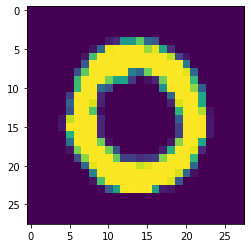

```python
#To start we will load and format the training data in python:

trainData = pd.read_csv("./Data/MNIST_train.csv")
train_y = trainData['label'].to_numpy()
train_x = trainData.to_numpy()
train_x = train_x[:,1:train_x.shape[1]]
#turn our data into torch tensors
train_y = torch.from_numpy(train_y)
train_x = torch.from_numpy(train_x)
#We now need to reshape train_x so that it is in the correct format for the image classifier
train_x = train_x.view(train_x.shape[0], 1, int(np.sqrt(train_x.shape[1])), int(np.sqrt(train_x.shape[1])))

#Now we'll look an image and write a function that will take a tensor and show the plot of the image
import matplotlib.pyplot as plt

def TImShow(image):
    image = image[0,:,:]
    #need to be in cpu to use the numpy() command
    plt.imshow(image.cpu().detach().numpy())
    plt.show()
TImShow(train_x[1,:,:,:])
```

```
The generator's first attempt at generating an image:
```

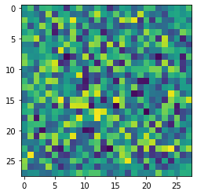

```
[1,   656] loss: 3.059
```

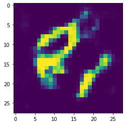

```
[2,   656] loss: 6.797
```

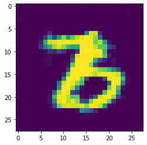

```
[3,   656] loss: 8.150
```

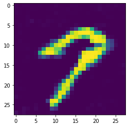

```
[4,   656] loss: 8.950
```

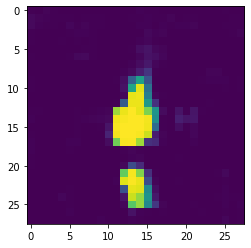

```
[5,   656] loss: 9.243
```

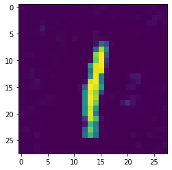

```
[6,   656] loss: 9.720
```

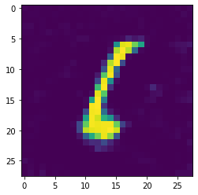

```
[7,   656] loss: 9.918
```

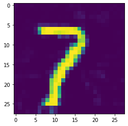

```
[8,   656] loss: 10.015
```

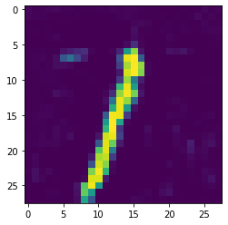

```
[9,   656] loss: 9.982
```

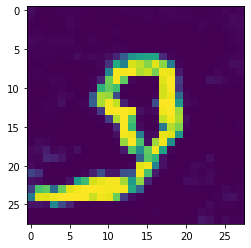

```
[10,   656] loss: 9.990
```

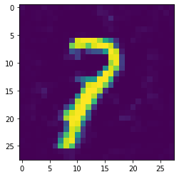

```
Done traininig
```

```python
def getRealSamples(data, batch_size):
    temp = torch.randperm(batch_size)
    result = data[temp, :, :, :]
    #rescale to match generator, normall grey scale ranges from [0,255], so to do this rescale we will subtrack by the mid point and divide by the mid point
    #(this will force all the values to be between -1 and 1)
    result = result.float()
    result = (result - 255/2)/(255/2)
    return result
gen = Generator(64,32).cuda()
dis = Discriminator().cuda()
batch_size = 64
#define our two optimizers
learning_rate = 5e-5
#Use two separate RMSprop optimizers, one for the generator and one for the discriminator
gOptimizer = torch.optim.RMSprop(gen.parameters(), lr=learning_rate)
dOptimizer = torch.optim.RMSprop(dis.parameters(), lr=learning_rate)
#Now we will define the training loop:
epochs = 10
batchesPerEpoch = int(np.floor(train_x.shape[0]/batch_size))
for epoch in range(epochs):
    running_gen_loss = 0
    for i in range(batchesPerEpoch):
        #number of times we train the critic for each training step on the generator
        criticConst = 5
        for j in range(criticConst):
            #set the gradients of the discriminator to zero
            dOptimizer.zero_grad()
            #generate a mini batch of gaussian noise
            genMiniBatch = torch.rand(batch_size, 100).float()
            genMiniBatch = genMiniBatch.cuda()
            #get a minibatch of the real data
            realMiniBatch = getRealSamples(train_x, batch_size)
            realMiniBatch = realMiniBatch.cuda()

            #Start by training the discriminator
            #Get Dx, the discriminator when applied to the minibatch of real data
            Dx = dis(realMiniBatch)
            #calculate the loss associated with this step
            dxLoss = -1*torch.mean(Dx)
            #find the gradients for this step
            dxLoss.backward()
            #generate fake images
            Gz = gen(genMiniBatch.float())
            #apply the discriminator to fake images
            Gz = Gz.view(batch_size, 1, 28, 28)
            Gz = Gz.cuda()
            DGz = dis(Gz)
            #Find the loss associated with this step
            dgzLoss = 1*torch.mean(DGz)
            #Accumulate the gradients for this half of the loss
            dgzLoss.backward()
            #set the total loss as the sum of our two previous losses
            dLoss = dgzLoss+dxLoss
            dOptimizer.step()
            #weight clipping. I used https://discuss.pytorch.org/t/set-constraints-on-parameters-or-layers/23620/7 as a reference
            #it appears that j.data will allow us to modify non-leaf nodes of our computational graph despite the fact that they require gradients.
            #It also appears that this feature is depreciated, and it shouldn't be used until after our optimizer has taken a step because it might mess
            #with the backpropogation. Note: the .clamp_ function does exactly what one would think (it makes sure that all the values of a tensor are
            #within the given range) and the _ denotes that the operation is an inplace operation.
            for j in dis.parameters():
                j.data.clamp_(-.1,.1)


        #set the generator's gradients to zero
        gOptimizer.zero_grad()
        genMiniBatch = torch.rand(batch_size*2, 100)
        genMiniBatch = genMiniBatch.cuda()
        #use the generator to make a new batch of images (even though we have already computed this we need to recompute it for pytorch to understand
        #how to backpropogate)
        Gz = gen(genMiniBatch.float())
        #apply the discriminator to the generated images
        Gz = Gz.view(batch_size*2, 1, 28, 28)
        Gz = Gz.cuda()
        DGz = dis(Gz)
        #calculate the loss
        gLoss = -1*torch.mean(DGz)
        #accumulate the gradients
        gLoss.backward()
        gOptimizer.step()

        if epoch == 0 and i == 0:
            print("The generator's first attempt at generating an image: ")
            Gz = Gz.view(batch_size*2,1,28,28)
            TImShow(Gz[0,:,:,:].cpu())
        # print statistics and image
        running_gen_loss += gLoss.item()
        if i == batchesPerEpoch-1:    # print every 2000 mini-batches
            print('[%d, %5d] loss: %.3f' %
                  (epoch + 1, i + 1, running_gen_loss/batchesPerEpoch))
            Gz = Gz.view(batch_size*2,1,28,28)
            TImShow(Gz[0,:,:,:].cpu())
            #running_gen_loss = 0.0

print("Done traininig")
```

It doesn't look like mode collapse is a huge issue with this data, but more training would be required to get a good convergence, though after a mere 10 iterations this is getting some plausible numbers, which is impressive given the results that I found in my second biweekly report. In that experiment there were still artifacts in the background at 20 epochs, so the fact that this has already learned how to generate a defined shape with almost no issues in the background is impressive.